# IF540_Kelas EL_00000054804_Christopher Darren_Week06

## TUGAS LAB IF540 MACHINE LEARNING

### WEEK 06 : Instance Based Learning

#### Semester Genap 2022/2023

```python
# Run this code when you restart the machine
# Fill in with YOUR name and NIM
import datetime
import uuid

myName = "Christopher Darren"
myNIM = "00000054804"
```

```python
myDate = datetime.datetime.now()
myDevice = str(uuid.uuid1())

print("Name: \t\t{}".format(myName))
print("NIM: \t\t{}".format(myNIM))
print("Start: \t\t{}".format(myDate))
print("Device ID: \t{}".format(myDevice))
```

```
Name: 		Christopher Darren
NIM: 		00000054804
Start: 		2023-03-16 08:19:37.227855
Device ID: 	9e0a5f1f-c398-11ed-a857-f02f74a116e8
```

### Dataset yang dipakai:

1. Air – sumber : https://www.kaggle.com/datasets/fedesoriano/air-quality-data-set

### Hasil kerja

#### Importing system library

```python
import sys
```

#### Importing libraries

```python
import numpy as np
import sklearn.datasets
import mglearn
import matplotlib.pyplot as plt
```

```
X.shape: (26, 2)
```

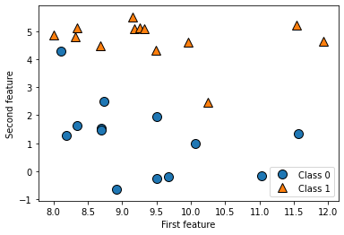

```python
X, y = mglearn.datasets.make_forge()
# plot dataset
mglearn.discrete_scatter(X[:, 0], X[:, 1], y)
plt.legend(["Class 0","Class 1"], loc=4)
plt.xlabel("First feature")
plt.ylabel("Second feature")
print("X.shape: {}".format(X.shape))
```

```
Target: [1 1 1 0 0 0 0 0 1 0 1 1 0 0 1 1 0 0 1 1 1 0 0 1 0 1 0 1 0 1 1 0 0 0 1 1 1
 1 0 1 0 0 0 1 0 0 0 0 0 1 0 0 0 1 1 0 1 1 1 1 1 1 1 1 1 1 1 0 0 1 1 1 1 1
 0 0 0 1 0 0 0 0 1 0 1 0 1 0 1 0 0 1 1 0 0 0 1 1 0 0]
X.shape: (100, 2)
```

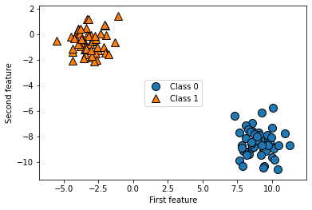

```python
X, y = mglearn.datasets.make_blobs()
# plot dataset
mglearn.discrete_scatter(X[:, 0], X[:, 1], y)
plt.legend(["Class 0","Class 1"], loc=10)
plt.xlabel("First feature")
plt.ylabel("Second feature")

print("Target:", y)
print("X.shape: {}".format(X.shape))
```

### Test generate data sendiri

```
Target: [1 1 0 2 0 0 2 2 2 2 1 1 0 0 1 2 1 2 0 1 1 2 0 0 0 0 0 2 1 2 2 1 1 1 0 2 0
 2 2 0 2 0 2 2 0 1 2 1 2 1 2 1 2 2 0 0 0 0 0 2 0 2 2 2 2 2 0 1 0 2 1 0 2 1
 2 1 1 1 2 1 1 0 0 0 0 2 1 2 2 0 2 1 1 1 1 2 0 1 0 0 1 0 1 1 0 2 2 0 1 1 1
 1 0 0 1 0 2 1 0 2 1 0 1 2 0 0 1 0 2 1 2 1 0 0 1 0 0 0 1 0 0 2 1 0 0 2 0 2
 0 0 1 1 0 0 0 1 0 2 0 2 1 2 0 1 2 1 2 2 1 2 0 1 2 2 0 2 1 1 1 1 2 2 1 0 2
 0 1 2 1 1 1 1 0 1 0 1 2 2 2 1 0 0 1 1 1 2 0 1 0 1 2 0 0 2 1 0 2 0 0 1 1 2
 1 2 1 2 0 2 1 1 1 1 1 0 2 2 1 2 2 2 0 1 1 1 2 2 1 0 0 0 2 1 2 2 2 1 2 1 2
 1 0 1 0 0 2 1 2 1 1 0 1 2 2 2 0 0 0 1 1 1 0 2 2 2 0 2 1 0 1 1 0 2 0 0 0 0
 1 2 0 2 2 0 1 1 0 0 2 1 0 0 2 1 0 1 1 2 0 1 1 1 0 2 1 2 2 0 2 0 2 1 2 2 2
 2 1 2 2 0 0 2 0 2 0 0 2 1 1 2 0 2 1 0 0 0 2 2 1 2 1 0 1 1 1 0 1 0 0 0 1 2
 2 1 1 2 1 2 2 0 0 2 1 0 1 1 1 2 2 1 2 2 1 1 2 2 2 2 0 0 1 0 0 0 1 2 2 2 1
 1 1 1 0 1 0 0 0 0 2 1 0 0 0 0 2 1 2 1 1 2 1 1 0 2 0 0 2 2 0 2 1 1 1 0 1 2
 2 1 1 0 1 2 2 2 0 1 2 0 0 0 1 2 0 0 1 2 0 1 2 0 1 2 1 1 0 0 0 0 2 2 1 2 0
 1 0 0 2 1 0 0 2 2 2 2 2 2 0 1 0 0 0 2]
X.shape: (500, 20)
```

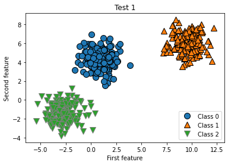

```python
from sklearn.datasets import make_blobs
X, y = make_blobs(n_samples=500, n_features=20, random_state=0)

#plot dataset
mglearn.discrete_scatter(X[:, 0], X[:, 1], y)
plt.legend(["Class 0","Class 1", "Class 2"], loc=4)
plt.xlabel("First feature")
plt.ylabel("Second feature")
plt.title("Test 1")

print("Target:", y)
print("X.shape: {}".format(X.shape))
```

```
Target: [1 1 0 2 2 1 0 0 2 1 2 2 2 2 0 1 1 2 0 1 1 2 0 0 0 0 0 2 2 0 1 2 0 0 1 2 1
 2 1 2 1 1 1 0 2 0 2 2 0 0 1 1 0 0 1 2 1 0 0 0 2 2 0 1 2 0 2 0 2 0 1 0 1 2
 1 1 2 1 0 1 2 1 2 0 0 2 0 2 1 2 1 2 0 0 1 1 1 1 1 0 1 1 2 0 0 2 0 1 2 0 2
 2 1 1 0 0 1 0 0 0 2 1 1 1 2 1 1 1 1 0 2 2 0 1 0 1 0 1 2 0 0 1 0 0 2 0 1 0
 0 2 2 1 0 1 0 2 0 2 1 0 2 2 0 1 2 2 2 1 2 1 1 2 1 2 1 2 0 2 1 1 0 2 0 1 2
 1 0 1 2 2 0 2 1 0 0 2 2 1 2 2 0 2 2 1 1 1 2 0 2 0 1 1 0 2 1 0 0 0 0 2 0 2
 0 1 1 2 1 2 0 1 2 1 1 0 0 2 0 0 2 2 2 1 2 1 0 2 0 1 1 2 1 1 1 2 0 1 0 0 2
 1 0 1 1 1 0 1 0 2 1 2 1 2 0 1 1 1 0 2 0 2 0 1 0 1 1 2 2 0 0 2 1 0 1 2 0 2
 1 2 0 0 0 0 0 0 2 0 0 0 1 1 0 1 2 0 2 0 1 2 0 0 2 2 1 1 2 2 0 2 2 2 1 2 1
 1 0 0 2 0 2 1 0 2 1 0 1 0 1 2 2 0 2 2 1 1 2 2 1 1 1 0 2 1 2 2 1 2 0 1 2 2
 0 1 0 0 1 0 2 2 0 1 2 2 2 2 2 0 1 0 0 2 2 2 0 1 1 0 1 2 2 1 2 2 1 0 0 1 2
 0 0 0 1 0 2 1 0 0 0 0 2 2 1 2 0 1 1 1 2 1 2 0 0 2 2 0 2 2 0 2 2 1 0 0 2 2
 2 2 1 0 1 0 2 1 2 2 1 0 1 2 0 0 1 1 2 1 2 1 0 1 2 0 0 2 2 1 2 2 1 1 2 0 2
 2 1 1 0 1 0 2 1 2 2 0 1 0 0 2 1 0 2 1 0 2 1 1 1 0 1 1 0 2 2 1 0 2 1 1 0 1
 1 0 1 1 2 0 0 2 0 2 0 0 2 0 1 0 2 2 1 0 2 2 2 0 2 0 1 2 0 2 1 0 2 1 2 1 2
 1 2 0 1 0 1 0 1 0 0 0 0 2 0 2 0 0 0 2 1 0 2 0 0 2 0 0 0 0 2 0 2 1 1 2 2 1
 1 2 2 1 0 0 0 1 1 0 1 1 1 0 0 2 0 2 1 0 0 2 1 1 1 1 0 2 2 1 2 1 2 2 0 1 2
 0 1 1 2 1 1 2 2 2 0 1 1 1 0 1 1 1 0 2 2 1 2 0 1 2 1 0 2 1 2 1 1 2 2 0 0 0
 0 1 2 1 2 1 2 1 0 0 1 0 0 1 2 0 2 1 1 1 0 1 2 0 0 2 2 2 1 2 0 0 2 1 0 1 1
 0 0 0 1 0 1 0 2 1 2 2 1 0 0 2 1 1 1 2 0 0 1 2 1 2 2 2 2 0 0 0 0 1 0 2 0 0
 1 0 2 2 2 1 2 1 2 2 0 0 1 1 1 2 1 1 0 1 1 2 0 0 1 0 1 2 1 0 2 2 1 2 1 0 0
 0 2 2 1 0 0 1 0 1 0 1 2 0 2 1 1 1 2 0 1 2 2 0]
X.shape: (800, 35)
```

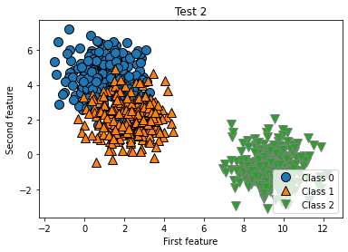

```python
from sklearn.datasets import make_blobs
X, y = make_blobs(n_samples=800, n_features=35, random_state=0)

#plot dataset
mglearn.discrete_scatter(X[:, 0], X[:, 1], y)
plt.legend(["Class 0","Class 1", "Class 2"], loc=4)
plt.xlabel("First feature")
plt.ylabel("Second feature")
plt.title("Test 2")

print("Target:", y)
print("X.shape: {}".format(X.shape))
```

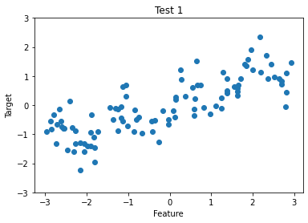

```python
X, y = mglearn.datasets.make_wave(n_samples=100)
plt.plot(X, y, 'o')
plt.ylim(-3,3)
plt.xlabel("Feature")
plt.ylabel("Target")
plt.title("Test 1")
```

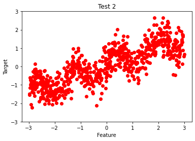

```python
X, y = mglearn.datasets.make_wave(n_samples=700)
plt.plot(X, y, 'o', color='red')
plt.ylim(-3,3)
plt.xlabel("Feature")
plt.ylabel("Target")
plt.title("Test 2")
```

#### Wisconsin Breast Cancer Data

#### Wisconsin Breast Cancer dataset (cancer, for short), which records clinical measurements of breast cancer tumors. Each tumor is labeled as “benign” (for harmless tumors) or “malignant” (for cancerous tumors)

```python
from sklearn.datasets import load_breast_cancer
cancer = load_breast_cancer()
print("cancer.key(): \n{}".format(cancer.keys()))
```

```
cancer.key():
dict_keys(['data', 'target', 'frame', 'target_names', 'DESCR', 'feature_names', 'filename', 'data_module'])
```

```python
print("Features names:\n{}".format(cancer.feature_names))
```

```
Features names:
['mean radius' 'mean texture' 'mean perimeter' 'mean area'
 'mean smoothness' 'mean compactness' 'mean concavity'
 'mean concave points' 'mean symmetry' 'mean fractal dimension'
 'radius error' 'texture error' 'perimeter error' 'area error'
 'smoothness error' 'compactness error' 'concavity error'
 'concave points error' 'symmetry error' 'fractal dimension error'
 'worst radius' 'worst texture' 'worst perimeter' 'worst area'
 'worst smoothness' 'worst compactness' 'worst concavity'
 'worst concave points' 'worst symmetry' 'worst fractal dimension']
```

```python
from sklearn.datasets import load_boston
boston = load_boston()
print("Data shape: {}".format(boston.data.shape))
```

```
Data shape: (506, 13)
```

[output not shown]

```python
print("Feature names:\n{}".format(boston.feature_names))
```

```
Feature names:
['CRIM' 'ZN' 'INDUS' 'CHAS' 'NOX' 'RM' 'AGE' 'DIS' 'RAD' 'TAX' 'PTRATIO'
 'B' 'LSTAT']
```

#### We will not only consider crime rate and highway accessibility as features, but also the product of crime rate and highway accessibility. This derived dataset can be loaded using the load_extended_boston function:

```python
X, y = mglearn.datasets.load_extended_boston()
print("X.shape: {}".format(X.shape))
```

```
X.shape: (506, 104)
```

## K-Nearest Neighbour

#### The k-NN algorithm is arguably the simplest machine learning algorithm. Building the model consists only of storing the training dataset. To make a prediction for a new data point, the algorithm finds the closest data points in the training dataset—its “nearest neighbors.”

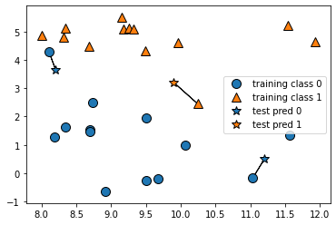

```python
mglearn.plots.plot_knn_classification(n_neighbors=1)
```

#### Instead of considering only the closest neighbor, we can also consider an arbitrary number, k, of neighbors. This is where the name of the k-nearest neighbors algorithm comes from. Try to change n_neighbors = 3.

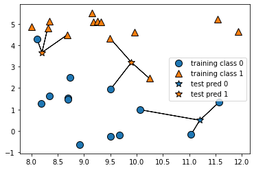

```python
mglearn.plots.plot_knn_classification(n_neighbors=3)
```

```python
from sklearn.model_selection import train_test_split
X, y = mglearn.datasets.make_forge()

X_train, X_test, y_train , y_test = train_test_split(X, y, random_state=0)
```

#### import and instantiate the class. This is when we can set parameters, like the number of neighbors to use. Here, we set it to 3.

```python
from sklearn.neighbors import KNeighborsClassifier
clf = KNeighborsClassifier(n_neighbors=3)
```

```python
clf.fit(X_train, y_train)
```

```
KNeighborsClassifier(n_neighbors=3)
```

#### To make predictions on the test data, we call the predict method. For each data point in the test set, this computes its nearest neighbors in the training set and finds the most common class among these.

```python
print("Test set: \n{} \n{}\n".format(X_test, y_test))
print("Test set predictions: {}".format(clf.predict(X_test)))
```

```
Test set:
[[11.54155807  5.21116083]
 [10.06393839  0.99078055]
 [ 9.49123469  4.33224792]
 [ 8.18378052  1.29564214]
 [ 8.30988863  4.80623966]
 [10.24028948  2.45544401]
 [ 8.34468785  1.63824349]]
[1 0 1 0 1 1 0]

Test set predictions: [1 0 1 0 1 0 0]
```

```python
print("Test set accuracy: {:.2f}".format(clf.score(X_test, y_test)))
```

```
Test set accuracy: 0.86
```

#### Analyzing KNeighborsClassifier

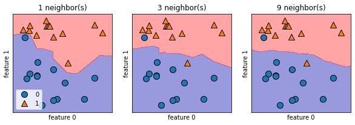

```python
fig, axes = plt.subplots(1, 3, figsize=(10,3))

for n_neighbors, ax in zip([1, 3, 9], axes):
    # the fit method return the object self , so we can instantiate
    # and fit in one line
    clf = KNeighborsClassifier(n_neighbors=n_neighbors).fit(X,y)
    mglearn.plots.plot_2d_separator(clf, X, fill=True, eps=0.5, ax=ax, alpha=.4)
    mglearn.discrete_scatter(X[:, 0], X[:, 1], y, ax=ax)
    ax.set_title("{} neighbor(s)".format(n_neighbors))
    ax.set_xlabel("feature 0")
    ax.set_ylabel("feature 1")
axes[0].legend(loc=3)
```

#### Let’s investigate whether we can confirm the connection between model complexity and generalization that we discussed earlier. We will do this on the real-world Breast Cancer dataset.

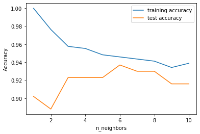

```python
from sklearn.datasets import load_breast_cancer
cancer = load_breast_cancer()

X_train, X_test, y_train, y_test = train_test_split(cancer.data, cancer.target, stratify=cancer.target, random_state=66)
training_accuracy = []
test_accuracy = []

# try n_neighbors in neighbors from 1 to 10
neighbors_settings = range(1, 11)

for n_neighbors in neighbors_settings:
    # build the model
    clf = KNeighborsClassifier(n_neighbors=n_neighbors)
    clf.fit(X_train, y_train)
    #record training set accuracy
    training_accuracy.append(clf.score(X_train, y_train))
    #record generalization accuracy
    test_accuracy.append(clf.score(X_test, y_test))

plt.plot(neighbors_settings, training_accuracy, label="training accuracy")
plt.plot(neighbors_settings, test_accuracy, label="test accuracy")
plt.ylabel("Accuracy")
plt.xlabel("n_neighbors")
plt.legend()
```

### k-Neighbors Regression

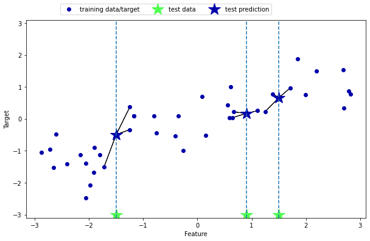

```python
mglearn.plots.plot_knn_regression(n_neighbors=3)
```

```python
from sklearn.neighbors import KNeighborsRegressor
X, y = mglearn.datasets.make_wave(n_samples=40)

# split the wave dataset into a training and a test set
X_train, X_test, y_train, y_test = train_test_split(X, y, random_state=0)

# instantiate the model an set the number of neighbors to consider to 3
reg = KNeighborsRegressor(n_neighbors=3)

# fit the model using the trainign data and training targets
reg.fit(X_train, y_train)

print("Test set: \n{} \n{}\n".format(X_test, y_test))
print("Test set predictions: \n{}".format(reg.predict(X_test)))
```

```
Test set:
[[-1.24713211]
 [ 0.67111737]
 [ 1.71105577]
 [-2.06388816]
 [-2.87649303]
 [-1.89957294]
 [ 0.55448741]
 [ 2.81945911]
 [-0.40832989]
 [-2.72129752]]
[ 0.37299129  0.21778193  0.96695428 -1.38773632 -1.05979555 -0.90496988
  0.43655826  0.7789638  -0.54114599 -0.95652133]

Test set predictions:
[-0.05396539  0.35686046  1.13671923 -1.89415682 -1.13881398 -1.63113382
  0.35686046  0.91241374 -0.44680446 -1.13881398]
```

```python
print("Test set R^2: {:.2f}".format(reg.score(X_test, y_test)))
```

```
Test set R^2: 0.83
```

#### Value of 1 corresponds to a perfect prediction, and a value of 0 corresponds to a constant model that just predicts the mean of the training set responses.

### Analyzing KNeighborsRegressor

#### The k-nearest neighbors classification algorithm is implemented in the KNeighborsClassifier class in the neighbors module. Before we can use the model, we need to instantiate the class into an object. This is when we will set any parameters of the model.

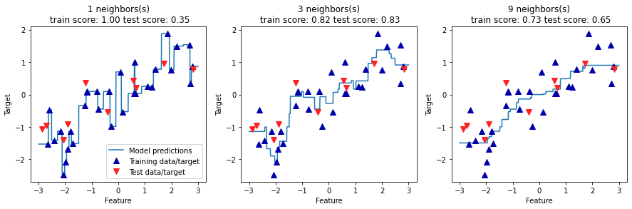

```python
fig, axes = plt.subplots( 1, 3, figsize=(15,4))
# create 1000 data points, evenly spaced between -3 and 3
line = np.linspace(-3, 3, 1000).reshape( -1, 1)

for n_neighbors, ax in zip([1, 3, 9], axes):
    # make predictions using 1, 3, or 9 neighbors
    reg = KNeighborsRegressor(n_neighbors=n_neighbors)
    reg.fit(X_train, y_train)
    ax.plot(line, reg.predict(line))
    ax.plot(X_train, y_train, '^', c=mglearn.cm2(0), markersize=8)
    ax.plot(X_test, y_test, 'v',c=mglearn.cm2(1), markersize=8)
    ax.set_title("{} neighbors(s)\n train score: {:.2f} test score: {:.2f}".format(
    n_neighbors, reg.score(X_train, y_train),
    reg.score(X_test, y_test)))
    ax.set_xlabel("Feature")
    ax.set_ylabel("Target")

axes[0].legend(["Model predictions", "Training data/target",
               "Test data/target"], loc="best")
```

## Challenge Dataset Sendiri

```python
import pandas as pd
import numpy as np
```

```python
angin = pd.read_csv(r"D:\SEMESTER 4\IF540 Machine Learning\LAB\week6\AirQuality.csv", delimiter=';')
angin.head(10)
```

|  | Date | Time | CO(GT) | PT08.S1(CO) | NMHC(GT) | C6H6(GT) | PT08.S2(NMHC) | NOx(GT) | PT08.S3(NOx) | NO2(GT) | PT08.S4(NO2) | PT08.S5(O3) | T | RH | AH | Unnamed: 15 | Unnamed: 16 |
| --- | --- | --- | --- | --- | --- | --- | --- | --- | --- | --- | --- | --- | --- | --- | --- | --- | --- |
| 0 | 10/03/2004 | 18.00.00 | 2,6 | 1360.0 | 150.0 | 11,9 | 1046.0 | 166.0 | 1056.0 | 113.0 | 1692.0 | 1268.0 | 13,6 | 48,9 | 0,7578 | NaN | NaN |
| 1 | 10/03/2004 | 19.00.00 | 2 | 1292.0 | 112.0 | 9,4 | 955.0 | 103.0 | 1174.0 | 92.0 | 1559.0 | 972.0 | 13,3 | 47,7 | 0,7255 | NaN | NaN |
| 2 | 10/03/2004 | 20.00.00 | 2,2 | 1402.0 | 88.0 | 9,0 | 939.0 | 131.0 | 1140.0 | 114.0 | 1555.0 | 1074.0 | 11,9 | 54,0 | 0,7502 | NaN | NaN |
| 3 | 10/03/2004 | 21.00.00 | 2,2 | 1376.0 | 80.0 | 9,2 | 948.0 | 172.0 | 1092.0 | 122.0 | 1584.0 | 1203.0 | 11,0 | 60,0 | 0,7867 | NaN | NaN |
| 4 | 10/03/2004 | 22.00.00 | 1,6 | 1272.0 | 51.0 | 6,5 | 836.0 | 131.0 | 1205.0 | 116.0 | 1490.0 | 1110.0 | 11,2 | 59,6 | 0,7888 | NaN | NaN |
| 5 | 10/03/2004 | 23.00.00 | 1,2 | 1197.0 | 38.0 | 4,7 | 750.0 | 89.0 | 1337.0 | 96.0 | 1393.0 | 949.0 | 11,2 | 59,2 | 0,7848 | NaN | NaN |
| 6 | 11/03/2004 | 00.00.00 | 1,2 | 1185.0 | 31.0 | 3,6 | 690.0 | 62.0 | 1462.0 | 77.0 | 1333.0 | 733.0 | 11,3 | 56,8 | 0,7603 | NaN | NaN |
| 7 | 11/03/2004 | 01.00.00 | 1 | 1136.0 | 31.0 | 3,3 | 672.0 | 62.0 | 1453.0 | 76.0 | 1333.0 | 730.0 | 10,7 | 60,0 | 0,7702 | NaN | NaN |
| 8 | 11/03/2004 | 02.00.00 | 0,9 | 1094.0 | 24.0 | 2,3 | 609.0 | 45.0 | 1579.0 | 60.0 | 1276.0 | 620.0 | 10,7 | 59,7 | 0,7648 | NaN | NaN |
| 9 | 11/03/2004 | 03.00.00 | 0,6 | 1010.0 | 19.0 | 1,7 | 561.0 | -200.0 | 1705.0 | -200.0 | 1235.0 | 501.0 | 10,3 | 60,2 | 0,7517 | NaN | NaN |

```python
angin.shape
angin.info()
```

```
<class 'pandas.core.frame.DataFrame'>
RangeIndex: 9471 entries, 0 to 9470
Data columns (total 17 columns):
 #   Column         Non-Null Count  Dtype
---  ------         --------------  -----
 0   Date           9357 non-null   object
 1   Time           9357 non-null   object
 2   CO(GT)         9357 non-null   object
 3   PT08.S1(CO)    9357 non-null   float64
 4   NMHC(GT)       9357 non-null   float64
 5   C6H6(GT)       9357 non-null   object
 6   PT08.S2(NMHC)  9357 non-null   float64
 7   NOx(GT)        9357 non-null   float64
 8   PT08.S3(NOx)   9357 non-null   float64
 9   NO2(GT)        9357 non-null   float64
 10  PT08.S4(NO2)   9357 non-null   float64
 11  PT08.S5(O3)    9357 non-null   float64
 12  T              9357 non-null   object
 13  RH             9357 non-null   object
 14  AH             9357 non-null   object
 15  Unnamed: 15    0 non-null      float64
 16  Unnamed: 16    0 non-null      float64
dtypes: float64(10), object(7)
memory usage: 1.2+ MB
```

```python
angin.isnull().values.any()
```

```
True
```

```python
angin.isnull().sum()
```

```
Date              114
Time              114
CO(GT)            114
PT08.S1(CO)       114
NMHC(GT)          114
C6H6(GT)          114
PT08.S2(NMHC)     114
NOx(GT)           114
PT08.S3(NOx)      114
NO2(GT)           114
PT08.S4(NO2)      114
PT08.S5(O3)       114
T                 114
RH                114
AH                114
Unnamed: 15      9471
Unnamed: 16      9471
dtype: int64
```

```python
angin = angin.dropna(how='all', axis=1)
angin.head(5)
```

|  | Date | Time | CO(GT) | PT08.S1(CO) | NMHC(GT) | C6H6(GT) | PT08.S2(NMHC) | NOx(GT) | PT08.S3(NOx) | NO2(GT) | PT08.S4(NO2) | PT08.S5(O3) | T | RH | AH |
| --- | --- | --- | --- | --- | --- | --- | --- | --- | --- | --- | --- | --- | --- | --- | --- |
| 0 | 10/03/2004 | 18.00.00 | 2,6 | 1360.0 | 150.0 | 11,9 | 1046.0 | 166.0 | 1056.0 | 113.0 | 1692.0 | 1268.0 | 13,6 | 48,9 | 0,7578 |
| 1 | 10/03/2004 | 19.00.00 | 2 | 1292.0 | 112.0 | 9,4 | 955.0 | 103.0 | 1174.0 | 92.0 | 1559.0 | 972.0 | 13,3 | 47,7 | 0,7255 |
| 2 | 10/03/2004 | 20.00.00 | 2,2 | 1402.0 | 88.0 | 9,0 | 939.0 | 131.0 | 1140.0 | 114.0 | 1555.0 | 1074.0 | 11,9 | 54,0 | 0,7502 |
| 3 | 10/03/2004 | 21.00.00 | 2,2 | 1376.0 | 80.0 | 9,2 | 948.0 | 172.0 | 1092.0 | 122.0 | 1584.0 | 1203.0 | 11,0 | 60,0 | 0,7867 |
| 4 | 10/03/2004 | 22.00.00 | 1,6 | 1272.0 | 51.0 | 6,5 | 836.0 | 131.0 | 1205.0 | 116.0 | 1490.0 | 1110.0 | 11,2 | 59,6 | 0,7888 |

```python
angin1 = angin.drop(['Date','Time','C6H6(GT)','T','RH','AH','CO(GT)'], axis=1)
angin1
```

|  | PT08.S1(CO) | NMHC(GT) | PT08.S2(NMHC) | NOx(GT) | PT08.S3(NOx) | NO2(GT) | PT08.S4(NO2) | PT08.S5(O3) |
| --- | --- | --- | --- | --- | --- | --- | --- | --- |
| 0 | 1360.0 | 150.0 | 1046.0 | 166.0 | 1056.0 | 113.0 | 1692.0 | 1268.0 |
| 1 | 1292.0 | 112.0 | 955.0 | 103.0 | 1174.0 | 92.0 | 1559.0 | 972.0 |
| 2 | 1402.0 | 88.0 | 939.0 | 131.0 | 1140.0 | 114.0 | 1555.0 | 1074.0 |
| 3 | 1376.0 | 80.0 | 948.0 | 172.0 | 1092.0 | 122.0 | 1584.0 | 1203.0 |
| 4 | 1272.0 | 51.0 | 836.0 | 131.0 | 1205.0 | 116.0 | 1490.0 | 1110.0 |
| ... | ... | ... | ... | ... | ... | ... | ... | ... |
| 9466 | NaN | NaN | NaN | NaN | NaN | NaN | NaN | NaN |
| 9467 | NaN | NaN | NaN | NaN | NaN | NaN | NaN | NaN |
| 9468 | NaN | NaN | NaN | NaN | NaN | NaN | NaN | NaN |
| 9469 | NaN | NaN | NaN | NaN | NaN | NaN | NaN | NaN |
| 9470 | NaN | NaN | NaN | NaN | NaN | NaN | NaN | NaN |

9471 rows × 8 columns

```python
print("airquality.keys(): \n{}".format(angin1.keys()))
```

```
airquality.keys():
Index(['PT08.S1(CO)', 'NMHC(GT)', 'PT08.S2(NMHC)', 'NOx(GT)', 'PT08.S3(NOx)',
       'NO2(GT)', 'PT08.S4(NO2)', 'PT08.S5(O3)'],
      dtype='object')
```

```python
#To get a description of the semantic meaning of each feature, we can have a look at the feature_names attribute
print("Features names:\n{}".format(angin1.columns))
```

```
Features names:
Index(['PT08.S1(CO)', 'NMHC(GT)', 'PT08.S2(NMHC)', 'NOx(GT)', 'PT08.S3(NOx)',
       'NO2(GT)', 'PT08.S4(NO2)', 'PT08.S5(O3)'],
      dtype='object')
```

```python
from sklearn.datasets import load_boston
print("Data shape: {}".format(angin1.shape))
```

```
Data shape: (9471, 8)
```

```python
print("Features names: \n{}".format(angin1.columns))
```

```
Features names:
Index(['PT08.S1(CO)', 'NMHC(GT)', 'PT08.S2(NMHC)', 'NOx(GT)', 'PT08.S3(NOx)',
       'NO2(GT)', 'PT08.S4(NO2)', 'PT08.S5(O3)'],
      dtype='object')
```

```python
print("X.shape: {}".format(X.shape))
```

[output not shown]

```python
X = angin1.iloc[:, :-1].values
y = angin1.iloc[: , 6].values
```

```python
from sklearn.model_selection import train_test_split

X_train, X_test, y_train , y_test = train_test_split(X, y, test_size=0.25 , random_state=0)
```

```python
from sklearn.preprocessing import StandardScaler
scaler = StandardScaler()
scaler.fit(X_train)
X_train = scaler.transform(X_train)
X_test = scaler.transform(X_test)
```

### saya menggunakan neighbors dengan jumlah n=3

```python
from sklearn.neighbors import KNeighborsClassifier
clf = KNeighborsClassifier(n_neighbors=3)
clf.fit(X_train, y_train)
```

[output not shown]

[output cut: 24 more lines]

[output not shown]

```python
y_pred = clf.predict(X_test)
```

[output not shown]

```python
#melihat nilai prediksi dari dataset air quality

print("Test set: \n{} \n{}\n".format(X_test, y_test))
print("Test set predictions: {}".format(clf.predict(X_test)))
```

[output not shown]

```python
print("Test set accuracy: {:.2f}".format(clf.score(X_test, y_test)))
```

[output not shown]

```python
from sklearn.datasets import load_breast_cancer
cancer = load_breast_cancer()

X_train, X_test, y_train, y_test = train_test_split(X , y, stratify=None, shuffle=False, random_state=0)
training_accuracy = []
test_accuracy = []

# try n_neighbors in neighbors from 1 to 10
neighbors_settings = range(1, 11)

for n_neighbors in neighbors_settings:
    # build the model
    clf = KNeighborsClassifier(n_neighbors=n_neighbors)
    clf.fit(X_train, y_train)
    #record training set accuracy
    training_accuracy.append(clf.score(X_train, y_train))
    #record generalization accuracy
    test_accuracy.append(clf.score(X_test, y_test))

plt.plot(neighbors_settings, training_accuracy, label="training accuracy")
plt.plot(neighbors_settings, test_accuracy, label="test accuracy")
plt.ylabel("Accuracy")
plt.xlabel("n_neighbors")
plt.legend()
```

[output not shown]

#### mari kita melakukan checking error terhadap test yang sudah dibuat

```python
error_rate = []
for i in range(1, 80):
    knn = KNeighborsClassifier(n_neighbors = i)
    knn.fit(X_train, y_train)
    pred_i = knn.predict(X_test)
    error_rate.append(np.mean(pred_i != y_test))
```

[output not shown]

#### kita menggunakan i= 1 sampe 79

[output not shown]

[figure not shown]

```python
plt.figure(figsize = (15, 10))
plt.plot(range(1, 80), error_rate, color = "purple", linestyle = "dashed", marker = "o", markerfacecolor = "yellow", markersize = 6)
plt.title("Error Rate vs. K Value", fontsize = 30)
plt.xlabel("K", fontsize = 50)
plt.ylabel("Error (misclassification) Rate")
```

```python
from sklearn.neighbors import KNeighborsRegressor
# memisahkan dataset menjadi data training dan data testing
X_train, X_test, y_train, y_test = train_test_split(X, y, shuffle = False, stratify = None, random_state = 0)
# masukkan number of neighbors sebesar 3
reg = KNeighborsRegressor(n_neighbors = 3)
# fit model menggunakan training data dan training targets
reg.fit(X_train, y_train)
print("Test set: \n{} \n{}\n".format(X_test, y_test))
print("Test set predictions: \n{}".format(reg.predict(X_test)))
```

[output not shown]

```python
print("Test set R^2: {:.2f}".format(reg.score(X_test, y_test)))
```

[output not shown]

```python
fig, axes = plt.subplots( 1, 3, figsize=(15,4))
# create 1000 data points, evenly spaced between -3 and 3
line = np.linspace(-3, 3, 1000).reshape(-7, 7)

for n_neighbors, ax in zip([1, 3, 9], axes):
    # make predictions using 1, 3, or 9 neighbors
    reg = KNeighborsRegressor(n_neighbors=n_neighbors)
    reg.fit(X_train, y_train)
    ax.plot(line, reg.predict(line))
    ax.plot(X_train, y_train, '^', c=mglearn.cm2(0), markersize=8)
    ax.plot(X_test, y_test, 'v',c=mglearn.cm2(1), markersize=8)
    ax.set_title("{} neighbors(s)\n train score: {:.2f} test score: {:.2f}".format(
    n_neighbors, reg.score(X_train, y_train),
    reg.score(X_test, y_test)))
    ax.set_xlabel("Feature")
    ax.set_ylabel("Target")

axes[0].legend(["Model predictions", "Training data/target",
               "Test data/target"], loc="best")
```

[output not shown]

### Kesimpulan

[output not shown]

```python
# Footer
myDate = datetime.datetime.now()
print("I certify that this is my own work.")
print("Signed by:")
print("Name: \t\t{}".format(myName))
print("NIM: \t\t{}".format(myNIM))
print("Time-stamp:\t{}".format(myDate))
```

```
I certify that this is my own work.
Signed by:
Name: 		Christopher Darren
NIM: 		00000054804
Time-stamp:	2023-03-22 12:04:47.456840
```

### Save the notebook, then convert the notebook to html (by running the next code).

```python
!jupyter nbconvert --to html "./IF540_Kelas EL_00000054804_Christopher Darren_Week06.ipynb" --output-dir="./"
```

```
[NbConvertApp] Converting notebook ./IF540_Kelas EL_00000054804_Christopher Darren_Week06.ipynb to html
[NbConvertApp] Writing 1107205 bytes to IF540_Kelas EL_00000054804_Christopher Darren_Week06.html
```